# Reproducible Research Course Project 1

Chester Sellers

5/14/2020

#Reproducible Research Course Project 1

## load my librarys

```r
library(ggplot2)
library(dplyr)
```

## Loading and preprocessing the data ### Q1

```r
activity <- read.csv("C:/Users/casel/Desktop/Coursera/Reproducible_Research/repdata_data_activity/activity.csv")
```

## View our Data

```r
View(activity)
```

## View a portion of data and its structure

```r
 head(activity)
```

```
##   steps       date interval
## 1    NA 2012-10-01        0
## 2    NA 2012-10-01        5
## 3    NA 2012-10-01       10
## 4    NA 2012-10-01       15
## 5    NA 2012-10-01       20
## 6    NA 2012-10-01       25
```

## Check basic statistics of the data

```r
 summary(activity)
```

```
##      steps                date          interval
##  Min.   :  0.00   2012-10-01:  288   Min.   :   0.0
##  1st Qu.:  0.00   2012-10-02:  288   1st Qu.: 588.8
##  Median :  0.00   2012-10-03:  288   Median :1177.5
##  Mean   : 37.38   2012-10-04:  288   Mean   :1177.5
##  3rd Qu.: 12.00   2012-10-05:  288   3rd Qu.:1766.2
##  Max.   :806.00   2012-10-06:  288   Max.   :2355.0
##  NA's   :2304     (Other)   :15840
```

## Check the column names

```r
 names(activity)
```

```
## [1] "steps"    "date"     "interval"
```

## basic pairs plot not really necesary

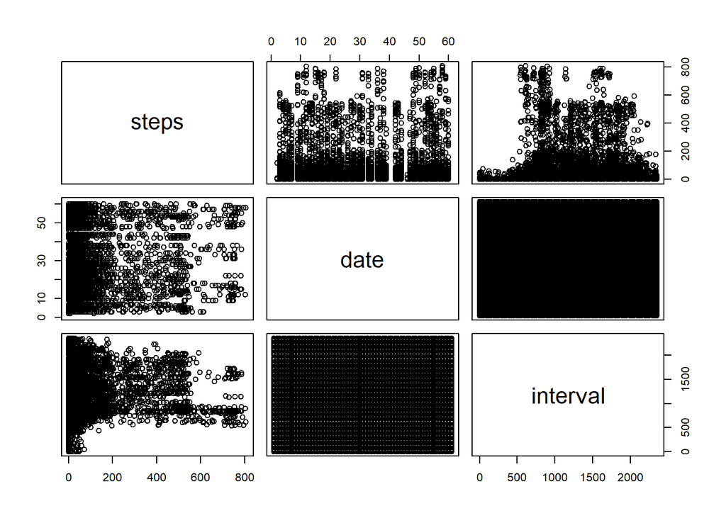

```r
  pairs(activity)
```

## What is mean total number of steps taken per day?###

```r
stepsDay <- aggregate(steps ~ date, activity, sum, na.rm=TRUE)
```

## View a portion of data and its structure

```r
  head(stepsDay)
```

```
##         date steps
## 1 2012-10-02   126
## 2 2012-10-03 11352
## 3 2012-10-04 12116
## 4 2012-10-05 13294
## 5 2012-10-06 15420
## 6 2012-10-07 11015
```

## Histogram of the total number of steps taken each day ## Q2

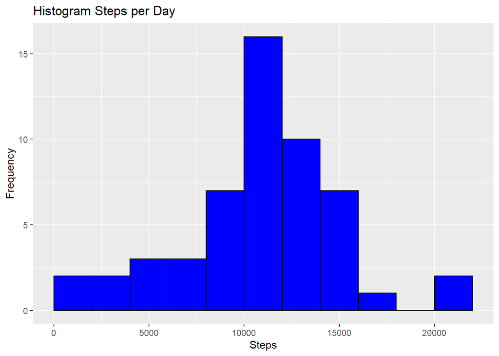

```r
  g <- ggplot(stepsDay, aes(steps))
  g+geom_histogram(boundary=0, binwidth=2000, col="black",fill="blue")+ggtitle("Histogram Steps per Day")+xlab("Steps")+ylab("Frequency")
```

## Mean and Median of the total number of steps taken per day ## Q3

## Get the Mean of steps per day

```r
  MeanStepsPerDay <- mean(stepsDay$steps)
```

## Result of Mean

```r
  MeanStepsPerDay
```

```
## [1] 10766.19
```

## Get the Median of steps per day

```r
  MedianStepsPerDay <- median(stepsDay$steps)
```

## Result of Median

```r
  MedianStepsPerDay
```

```
## [1] 10765
```

# What is the average daily activity pattern? ## Q4

## Variable with my Data SPT = Steps Pattern in Time

```r
  SPT <- aggregate(steps~interval,data=activity,FUN=mean,na.action=na.omit)
```

## Plot the result of Average Steps per Time Interval

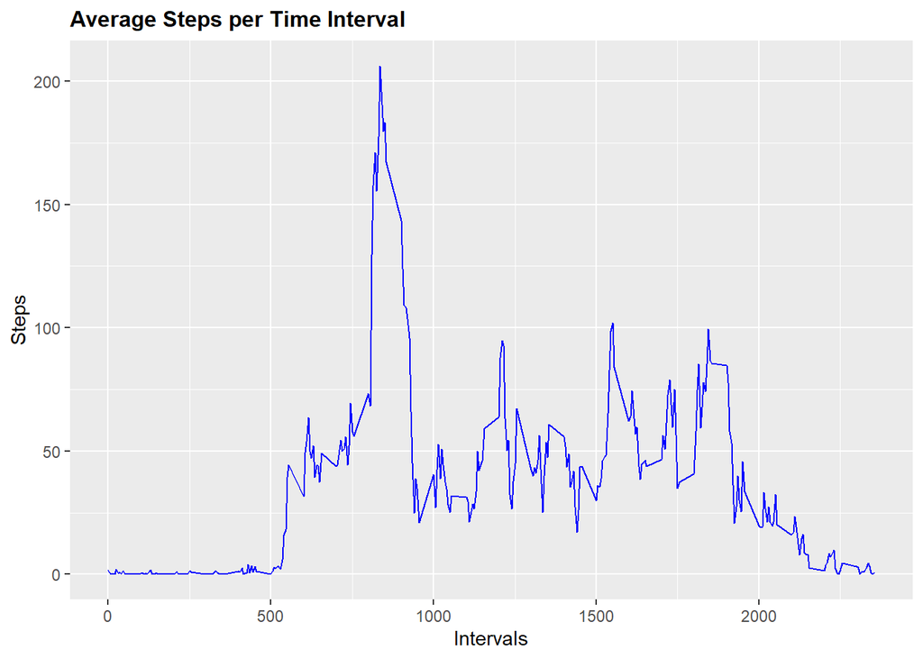

```r
  g1 <- ggplot(SPT, aes(interval, steps))
  g1+geom_line(col="blue")+ggtitle("Average Steps per Time Interval")+xlab("Intervals")+ylab("Steps")+theme(plot.title = element_text(face="bold", size=12))
```

## Which 5-minute interval, on average across all the days in the dataset, contains the maximum number of steps?

## Variable with my Data MISteps = Maximum Interval Steps

```r
  MISteps <- SPT[which.max(SPT$steps),]$interval
  MISteps
```

```
## [1] 835
```

# Imputing missing values ## Q5

## Calculate and report the total number of missing values in the dataset

```r
  TMValues <- sum(is.na(activity$steps))
  TMValues
```

```
## [1] 2304
```

## Devise a strategy for filling in all of the missing values in the dataset.

```r
  activity$fillSteps <- ifelse(is.na(activity$steps), round(SPT$steps[match(activity$interval, SPT$interval)],0), activity$steps)
```

### Create a new dataset that is equal to the original dataset but with the missing data filled in.

```r
  activityNoMissingData <- data.frame(steps=activity$fillSteps, interval=activity$interval, date=activity$date)
```

### Cheching top and bottom row of our data

```r
  head(activityNoMissingData)
```

```
##   steps interval       date
## 1     2        0 2012-10-01
## 2     0        5 2012-10-01
## 3     0       10 2012-10-01
## 4     0       15 2012-10-01
## 5     0       20 2012-10-01
## 6     2       25 2012-10-01
```

```r
  tail(activityNoMissingData)
```

```
##       steps interval       date
## 17563     3     2330 2012-11-30
## 17564     5     2335 2012-11-30
## 17565     3     2340 2012-11-30
## 17566     1     2345 2012-11-30
## 17567     0     2350 2012-11-30
## 17568     1     2355 2012-11-30
```

### Make a histogram of the total number of steps taken each day and calculate and report the mean and median total number of steps taken per day.

```r
  SPDNM <- aggregate(activityNoMissingData$steps, list(activityNoMissingData$date), FUN=sum)
```

### Checking my data and column names

```r
  head(SPDNM)
```

```
##      Group.1     x
## 1 2012-10-01 10762
## 2 2012-10-02   126
## 3 2012-10-03 11352
## 4 2012-10-04 12116
## 5 2012-10-05 13294
## 6 2012-10-06 15420
```

### Assing new header column names

```r
  colnames(SPDNM) <- c("Date", "Steps")
```

### Checking my data and column names

```r
  head(SPDNM)
```

```
##         Date Steps
## 1 2012-10-01 10762
## 2 2012-10-02   126
## 3 2012-10-03 11352
## 4 2012-10-04 12116
## 5 2012-10-05 13294
## 6 2012-10-06 15420
```

### Make a histogram

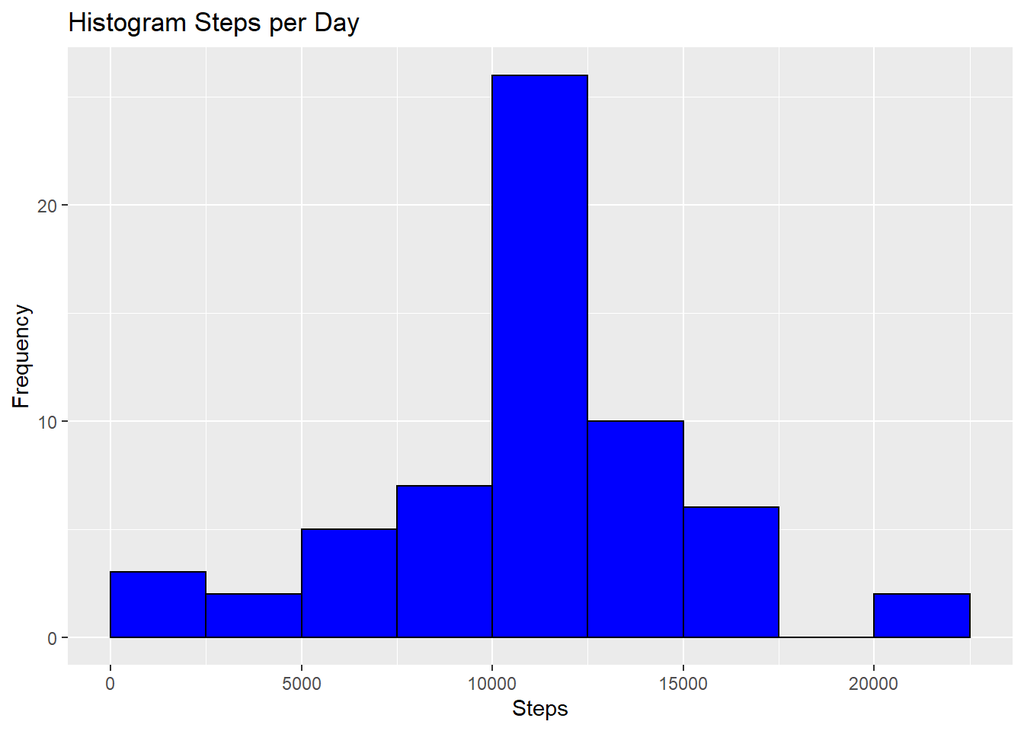

```r
  g3 <- ggplot(SPDNM, aes(Steps))
  g3+geom_histogram(boundary=0, binwidth=2500, col="black", fill="blue")+ggtitle("Histogram Steps per Day")+xlab("Steps")+ylab("Frequency")
```

## Calculate and report the mean and median total number of steps taken per day.

### Result of Mean

```r
  mean(SPDNM$Steps)
```

```
## [1] 10765.64
```

### Result of Median

```r
  median(SPDNM$Steps)
```

```
## [1] 10762
```

### Are there differences in activity patterns between weekdays and weekends? Q6

### Create variable with date in correct format

```r
    activityNoMissingData$RealDate <- as.Date(activityNoMissingData$date, format = "%Y-%m-%d")
    head(activityNoMissingData)
```

```
##   steps interval       date   RealDate
## 1     2        0 2012-10-01 2012-10-01
## 2     0        5 2012-10-01 2012-10-01
## 3     0       10 2012-10-01 2012-10-01
## 4     0       15 2012-10-01 2012-10-01
## 5     0       20 2012-10-01 2012-10-01
## 6     2       25 2012-10-01 2012-10-01
```

### Create a variable with weekdays name

```r
    activityNoMissingData$weekday <- weekdays(activityNoMissingData$RealDate)
    head(activityNoMissingData)
```

```
##   steps interval       date   RealDate weekday
## 1     2        0 2012-10-01 2012-10-01  Monday
## 2     0        5 2012-10-01 2012-10-01  Monday
## 3     0       10 2012-10-01 2012-10-01  Monday
## 4     0       15 2012-10-01 2012-10-01  Monday
## 5     0       20 2012-10-01 2012-10-01  Monday
## 6     2       25 2012-10-01 2012-10-01  Monday
```

### create a new variable indicating weekday or weekend

```r
      activityNoMissingData$DayType <- ifelse(activityNoMissingData$weekday=='Saturday' | activityNoMissingData$weekday=='Sunday', 'weekend','weekday')
```

### View and check our data

```r
    head(activityNoMissingData)
```

```
##   steps interval       date   RealDate weekday DayType
## 1     2        0 2012-10-01 2012-10-01  Monday weekday
## 2     0        5 2012-10-01 2012-10-01  Monday weekday
## 3     0       10 2012-10-01 2012-10-01  Monday weekday
## 4     0       15 2012-10-01 2012-10-01  Monday weekday
## 5     0       20 2012-10-01 2012-10-01  Monday weekday
## 6     2       25 2012-10-01 2012-10-01  Monday weekday
```

```r
    tail(activityNoMissingData)
```

```
##       steps interval       date   RealDate weekday DayType
## 17563     3     2330 2012-11-30 2012-11-30  Friday weekday
## 17564     5     2335 2012-11-30 2012-11-30  Friday weekday
## 17565     3     2340 2012-11-30 2012-11-30  Friday weekday
## 17566     1     2345 2012-11-30 2012-11-30  Friday weekday
## 17567     0     2350 2012-11-30 2012-11-30  Friday weekday
## 17568     1     2355 2012-11-30 2012-11-30  Friday weekday
```

### Make a panel plot containing a time series plot, type = “l”) of the 5-minute interval (x-axis) and the average number of steps taken, averaged across all weekday days or weekend days (y-axis)

### Create variable with steps per time across week days // weekend days

```r
    SPTDT <- aggregate(steps~interval+DayType,data=activityNoMissingData,FUN=mean)
```

### Time variable

```r
    SPTDT$time <- SPTDT$interval
```

### draw the line plots

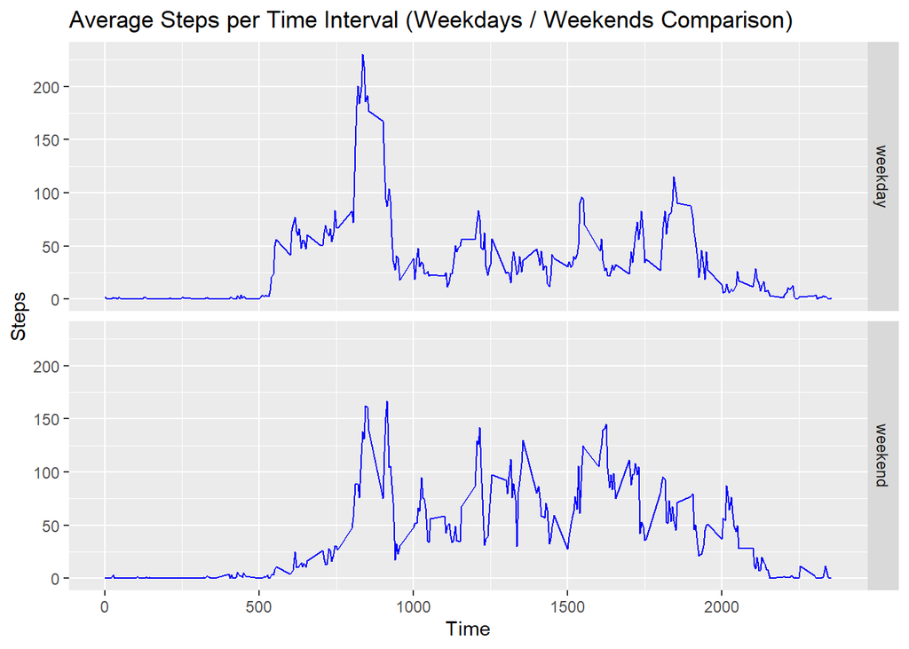

```r
    g4 <- ggplot(SPTDT, aes(time, steps))
    g4+geom_line(col="blue")+ggtitle("Average Steps per Time Interval (Weekdays / Weekends Comparison)")+xlab("Time")+ylab("Steps")+facet_grid(DayType ~ .)
```